# HW 7: Linear Models with Quantitative Regressors

Vidyullatha KS

2025-11-05

```r
# 1. Do not provide answers/comments inside code blocks (like here) -- those are notes between coders/self and will be ignored for grading.
# 2. Make sure your knitr options are set to include all results/code to be graded in the final document.
# 3. All charts/graphs/tables should have appropriate titles/labels/captions.
# 4. Compose your answers using inline R code instead of using the code-block output as much as you can.
# 5. Your grade is also determined by the style. Even if you answer everything correctly, but the .html does not look appealing, you will not get full credit. Pay attention to the details that we mentioned in class/homework and in previous sample .Rmd files. For example, how to use #, ##, ###, ..., bold face, italics, inline codes, tables, ..., {results = "asis"}, use of colors in plots/ggplots, and so forth.
```

This homework uses a bikeshare dataset called `BikeShare` on api.regression.fit, or *bikedata.csv* on our class GitHub repo.

# Question 1

**Import the data and name it `bikeorig`. Remove `Date`, `Casual Users`, and `Registered Users` from the dataset and save it as a new data frame named `bike`. How many variables are in `bike`? How many of them are imported as `int`? Feel free to rename longer variable names into shorter ones for convenience.**

```r
bikeorig <- read_csv("bikedata.csv")
glimpse(bikeorig)
```

```
## Rows: 17,379
## Columns: 14
## $ Date                  <chr> "1/1/2011", "1/1/2011", "1/1/2011", "1/1/2011", …
## $ Season                <dbl> 4, 4, 4, 4, 4, 4, 4, 4, 4, 4, 4, 4, 4, 4, 4, 4, …
## $ Hour                  <dbl> 0, 1, 2, 3, 4, 5, 6, 7, 8, 9, 10, 11, 12, 13, 14…
## $ Holiday               <dbl> 0, 0, 0, 0, 0, 0, 0, 0, 0, 0, 0, 0, 0, 0, 0, 0, …
## $ `Day of the Week`     <dbl> 6, 6, 6, 6, 6, 6, 6, 6, 6, 6, 6, 6, 6, 6, 6, 6, …
## $ `Working Day`         <dbl> 0, 0, 0, 0, 0, 0, 0, 0, 0, 0, 0, 0, 0, 0, 0, 0, …
## $ `Weather Type`        <dbl> 1, 1, 1, 1, 1, 2, 1, 1, 1, 1, 1, 1, 1, 2, 2, 2, …
## $ `Temperature F`       <dbl> 36.6, 34.9, 34.9, 36.6, 36.6, 36.6, 34.9, 33.1, …
## $ `Temperature Feels F` <dbl> 37.4, 35.6, 35.6, 37.4, 37.4, 33.8, 35.6, 33.8, …
## $ Humidity              <dbl> 81, 80, 80, 75, 75, 75, 80, 86, 75, 76, 76, 81, …
## $ `Wind Speed`          <dbl> 0, 0, 0, 0, 0, 6, 0, 0, 0, 0, 17, 19, 19, 20, 19…
## $ `Casual Users`        <dbl> 3, 8, 5, 3, 0, 0, 2, 1, 1, 8, 12, 26, 29, 47, 35…
## $ `Registered Users`    <dbl> 13, 32, 27, 10, 1, 1, 0, 2, 7, 6, 24, 30, 55, 47…
## $ `Total Users`         <dbl> 16, 40, 32, 13, 1, 1, 2, 3, 8, 14, 36, 56, 84, 9…
```

```r
summary(bikeorig)
```

```
##      Date               Season          Hour         Holiday
##  Length:17379       Min.   :1.00   Min.   : 0.0   Min.   :0.000
##  Class :character   1st Qu.:1.00   1st Qu.: 6.0   1st Qu.:0.000
##  Mode  :character   Median :2.00   Median :12.0   Median :0.000
##                     Mean   :2.49   Mean   :11.6   Mean   :0.029
##                     3rd Qu.:3.00   3rd Qu.:18.0   3rd Qu.:0.000
##                     Max.   :4.00   Max.   :23.0   Max.   :1.000
##  Day of the Week  Working Day     Weather Type  Temperature F
##  Min.   :0       Min.   :0.000   Min.   :1.00   Min.   : 17.6
##  1st Qu.:1       1st Qu.:0.000   1st Qu.:1.00   1st Qu.: 45.2
##  Median :3       Median :1.000   Median :1.00   Median : 59.0
##  Mean   :3       Mean   :0.683   Mean   :1.43   Mean   : 58.8
##  3rd Qu.:5       3rd Qu.:1.000   3rd Qu.:2.00   3rd Qu.: 72.8
##  Max.   :6       Max.   :1.000   Max.   :4.00   Max.   :102.2
##  Temperature Feels F    Humidity       Wind Speed    Casual Users
##  Min.   :  3.2       Min.   :  0.0   Min.   : 0.0   Min.   :  0
##  1st Qu.: 42.8       1st Qu.: 48.0   1st Qu.: 7.0   1st Qu.:  4
##  Median : 60.8       Median : 63.0   Median :13.0   Median : 17
##  Mean   : 59.7       Mean   : 62.7   Mean   :12.7   Mean   : 36
##  3rd Qu.: 77.0       3rd Qu.: 78.0   3rd Qu.:17.0   3rd Qu.: 48
##  Max.   :122.0       Max.   :100.0   Max.   :57.0   Max.   :367
##  Registered Users  Total Users
##  Min.   :  0      Min.   :  1
##  1st Qu.: 34      1st Qu.: 40
##  Median :115      Median :142
##  Mean   :154      Mean   :189
##  3rd Qu.:220      3rd Qu.:281
##  Max.   :886      Max.   :977
```

Imported the data and above is a quick peep at the data and summary

```r
library(janitor)
bikeorig <- bikeorig %>% janitor::clean_names()
bike <- bikeorig %>%
  select(-date, -casual_users, -registered_users)

num_vars <- ncol(bike)
int_cols <- sapply(bike, function(x) inherits(x, "integer"))
num_ints <- sum(int_cols)
```

The bike data frame contains 11 variables. Of these, 0 were imported as integer type

**Note:** None of them were imported as integer (all are numeric), because R reads CSV numbers as numeric by default.

# Question 2

**Select the subset with `Hour` equal 16 only and name the new data frame `bike16`. These are the afternoon rush hour data. How many observations are there? Use this data frame for the next question.**

```r
bike16 <- bike %>% filter(hour == 16)
n_bike16 <- nrow(bike16)
n_bike16
```

```
## [1] 730
```

The bike16 data frame (hour == 16) has 730 observations

# Question 3

**Before building any models, we should make sure the variables are set up properly in `bike16`. Which ones should be recorded as categorical? Convert them now before proceeding to the model building. Call this *cleaned* dataset `bike16_final` and use it for the rest of the questions.**

```r
categorical_vars <- c("hour", "season", "weather", "holiday", "workingday", "weekday")
categorical_vars <- categorical_vars[categorical_vars %in% names(bike16)]

bike16_final <- bike16 %>%
  mutate(across(all_of(categorical_vars), ~ factor(.x)))

str(bike16_final)
```

```
## tibble [730 × 11] (S3: tbl_df/tbl/data.frame)
##  $ season             : Factor w/ 4 levels "1","2","3","4": 4 4 4 4 4 4 4 4 4 4 ...
##  $ hour               : Factor w/ 1 level "16": 1 1 1 1 1 1 1 1 1 1 ...
##  $ holiday            : Factor w/ 2 levels "0","1": 1 1 1 1 1 1 1 1 1 1 ...
##  $ day_of_the_week    : num [1:730] 6 0 1 2 3 4 5 6 0 1 ...
##  $ working_day        : num [1:730] 0 0 1 1 1 1 1 0 0 1 ...
##  $ weather_type       : num [1:730] 2 3 1 1 1 1 2 1 1 1 ...
##  $ temperature_f      : num [1:730] 52.1 45.2 38.3 41.8 41.8 38.3 33.1 31.4 33.1 33.1 ...
##  $ temperature_feels_f: num [1:730] 53.6 42.8 32 37.4 41 33.8 28.4 19.4 23 28.4 ...
##  $ humidity           : num [1:730] 82 71 30 49 28 38 37 29 34 40 ...
##  $ wind_speed         : num [1:730] 20 11 17 17 6 11 11 30 30 9 ...
##  $ total_users        : num [1:730] 93 76 76 83 89 86 87 76 92 74 ...
```

I converted the following variables to categorical (factor) type: hour, season, holiday. This ensures that variables like hour, season, and holiday are treated as categorical in the model.

# Question 4

**Make a `pairs()` plot with all the variables (quantitative and qualitative) in the `bike16_final` dataset.**

Note: While the `cor()` function does not accept categorical variables (and therefore we cannot use it for `corrplot()`), the `lattice::pairs()` function does not complain about categorical columns. We can still use it to get a visual distribution of data values from it.

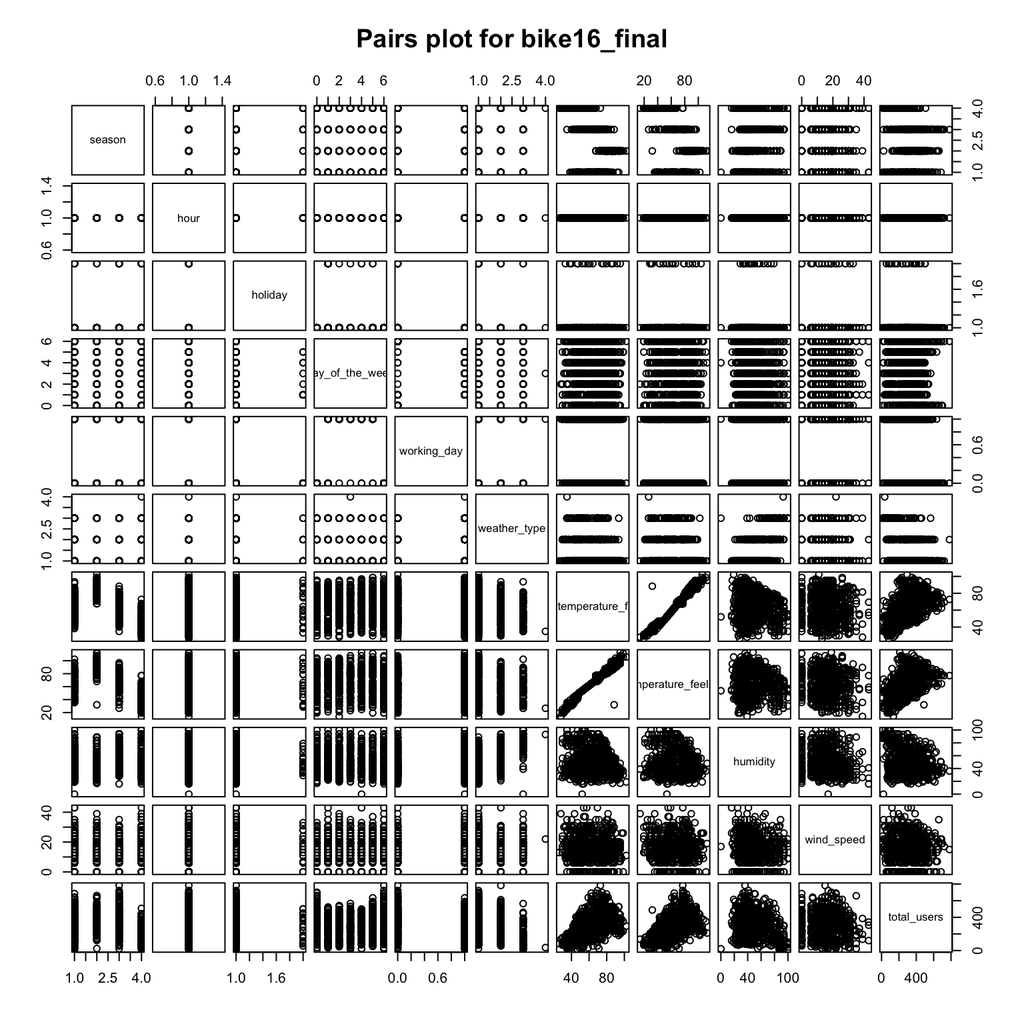

```r
pairs(bike16_final, gap = 0.5, main = "Pairs plot for bike16_final")
```

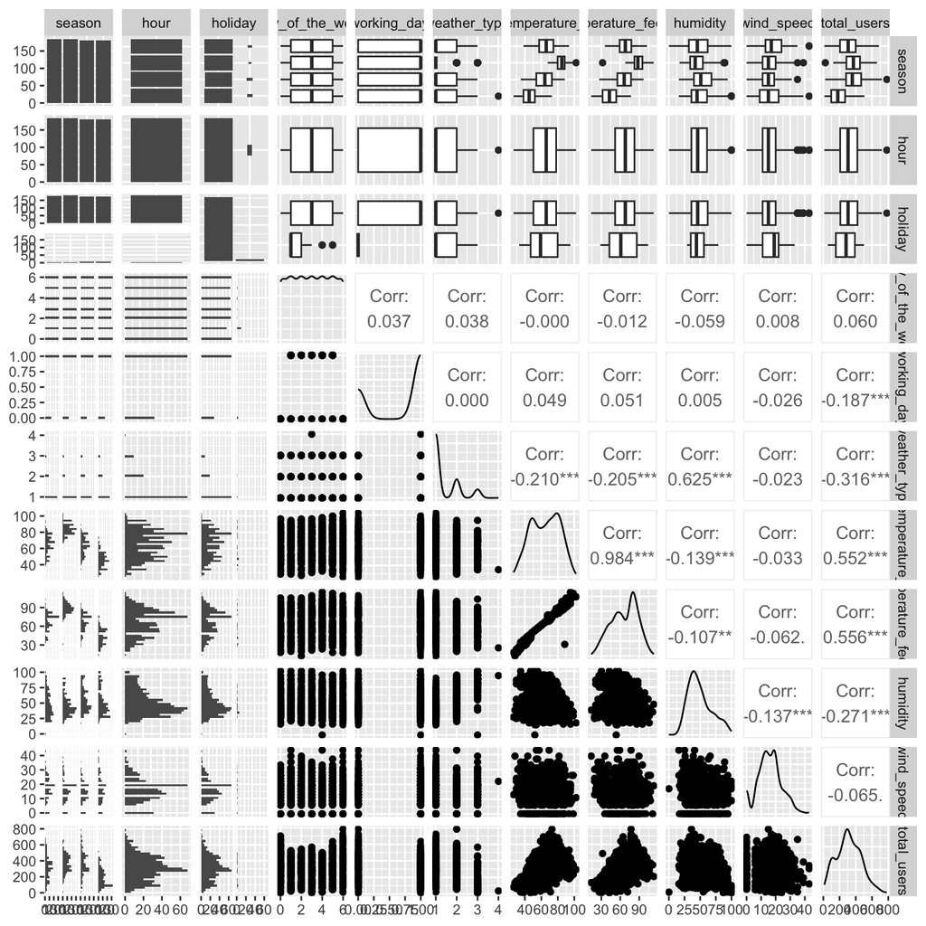

```r
library(GGally)
ggpairs(bike16_final)
```

The pairs plot (`pairs(bike16_final)`) allows us to visually inspect relationships between variables. We can see that `total_users` tends to increase with `temperature_f` and `temperature_feels_f`. Other variables show weaker relationships.

# Question 5

**Make a `corrplot()` with only the numerical variables in the `bike16_final` dataset.**

Note: correlation functions will not work with categorical/factor variables. You can either subset the data frame to only numerical variables first, then create the correlation matrix to plot. Or you can create the correlation matrix from `bike16_final`, then select out the portion of the matrix that you want. Use options that does a good job showing the relationships between different variables.

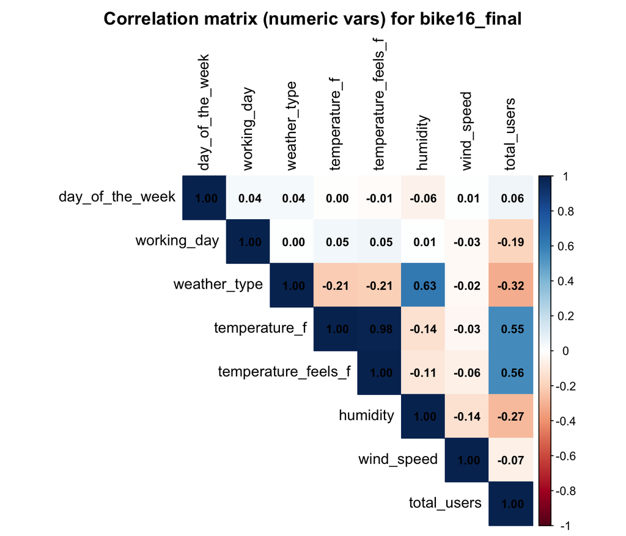

```r
library(corrplot)
num_df <- bike16_final %>% select(where(is.numeric))

# computing correlation matrix
cor_mat <- cor(num_df, use = "pairwise.complete.obs", method = "pearson")

# corrplot
corrplot(cor_mat, method = "color", type = "upper",
         addCoef.col = "black", tl.col = "black", number.cex = 0.8,
         title = "Correlation matrix (numeric vars) for bike16_final", mar=c(0,0,2,0))
```

# Question 6

**Using only the numerical variables from the `bike16_final` dataset, build a linear model with 1 independent variable to predict the `Total Users`. Choose the variable with the strongest correlation coefficient. State and interpret the coefficient values, their p-values, and the multiple R-squared value.**

```r
response_var <- "total_users"

# correlation of numeric predictors with response
cors_with_resp <- cor_mat[, response_var] %>% sort(decreasing = TRUE)

# removing self
cors_with_resp <- cors_with_resp[names(cors_with_resp) != response_var]
cors_with_resp
```

```
## temperature_feels_f       temperature_f     day_of_the_week          wind_speed
##              0.5560              0.5518              0.0599             -0.0653
##         working_day            humidity        weather_type
##             -0.1866             -0.2706             -0.3161
```

```r
# picking top predictor by absolute correlation
top_predictor <- names(which.max(abs(cors_with_resp)))
top_predictor
```

```
## [1] "temperature_feels_f"
```

```r
# Fit single-variable model
formula1 <- as.formula(paste(response_var, "~", top_predictor))
model1 <- lm(formula1, data = bike16_final)

summary(model1)
```

```
##
## Call:
## lm(formula = formula1, data = bike16_final)
##
## Residuals:
##    Min     1Q Median     3Q    Max
## -308.7  -88.9   -5.6   78.7  428.6
##
## Coefficients:
##                     Estimate Std. Error t value Pr(>|t|)
## (Intercept)           44.530     15.510    2.87   0.0042 **
## temperature_feels_f    4.024      0.223   18.05   <2e-16 ***
## ---
## Signif. codes:  0 '***' 0.001 '**' 0.01 '*' 0.05 '.' 0.1 ' ' 1
##
## Residual standard error: 124 on 728 degrees of freedom
## Multiple R-squared:  0.309,  Adjusted R-squared:  0.308
## F-statistic:  326 on 1 and 728 DF,  p-value: <2e-16
```

The single-variable linear model predicts Total Users using temperature_feels_f. The estimated regression equation is: Total_Users = 44.53 + (4.024) * temperature_feels_f. This means that for every one unit increase in temperature_feels_f, Total Users changes by 4.024 users. The coefficient is statistically significant (p < 0.001), and the model explains 0.309 of the variance in Total Users (R-squared).

# Question 7

**Write down the regression equation for the model fit in Q6.**

Hint: The regression model equation will look something like `Total users` = 0.28 + 5.29 `Temperature F`, just as an example.

```r
coefs <- coef(model1)
eq_text <- sprintf("Total_Users = %.3f + (%.3f) * %s", coefs[1], coefs[2], top_predictor)
eq_text
```

```
## [1] "Total_Users = 44.530 + (4.024) * temperature_feels_f"
```

The regression equation based on the model from Q6 is: Total_Users = 44.530 + (4.024) * temperature_feels_f.

# Question 8

**Next, add a second quantitative variable to the model. Choose the variable with the next strongest correlation, but avoid using obviously collinear variables (`Temperature F` and `Temperature Feels F` for example). State and interpret the coefficient values, their p-values, and the multiple R-squared value.**

Note: When you have the model, check the VIF values. If the VIF is higher than 5, discard this model, and try the variable with the next strongest correlation until you find one that works (ideally with VIF<5, or if you have to, allow VIF up to 10).

```r
# -- Code Reference : ChatGPT
library(car)
# candidate predictors ordered by absolute correlation (excluding response)
cand_order <- names(sort(abs(cors_with_resp), decreasing = TRUE))
cand_order
```

```
## [1] "temperature_feels_f" "temperature_f"       "weather_type"
## [4] "humidity"            "working_day"         "wind_speed"
## [7] "day_of_the_week"
```

```r
# Avoid extremely collinear predictors by checking vif
model2 <- NULL
chosen_second <- NA
first_pred <- top_predictor

for (cand in cand_order) {
  if (cand == first_pred) next
  formula2 <- as.formula(paste(response_var, "~", first_pred, "+", cand))
  tmp_mod <- lm(formula2, data = bike16_final)
  # computing VIFs
  vif_vals <- tryCatch(car::vif(tmp_mod), error = function(e) NA)
  max_vif <- if (is.numeric(vif_vals)) max(vif_vals, na.rm = TRUE) else Inf
  if (!is.infinite(max_vif) && max_vif < 5) {
    model2 <- tmp_mod
    chosen_second <- cand
    break
  }
}

# If there's no VIF<5, allow VIF<10
if (is.null(model2)) {
  for (cand in cand_order) {
    if (cand == first_pred) next
    formula2 <- as.formula(paste(response_var, "~", first_pred, "+", cand))
    tmp_mod <- lm(formula2, data = bike16_final)
    vif_vals <- tryCatch(car::vif(tmp_mod), error = function(e) NA)
    max_vif <- if (is.numeric(vif_vals)) max(vif_vals, na.rm = TRUE) else Inf
    if (!is.infinite(max_vif) && max_vif < 10) {
      model2 <- tmp_mod
      chosen_second <- cand
      break
    }
  }
}

# show chosen second predictor and model summary
chosen_second
```

```
## [1] "weather_type"
```

```r
summary(model2)
```

```
##
## Call:
## lm(formula = formula2, data = bike16_final)
##
## Residuals:
##    Min     1Q Median     3Q    Max
## -293.6  -86.6  -11.0   77.7  460.4
##
## Coefficients:
##                     Estimate Std. Error t value Pr(>|t|)
## (Intercept)          131.602     19.621    6.71  4.0e-11 ***
## temperature_feels_f    3.711      0.221   16.80  < 2e-16 ***
## weather_type         -47.366      6.858   -6.91  1.1e-11 ***
## ---
## Signif. codes:  0 '***' 0.001 '**' 0.01 '*' 0.05 '.' 0.1 ' ' 1
##
## Residual standard error: 120 on 727 degrees of freedom
## Multiple R-squared:  0.352,  Adjusted R-squared:  0.35
## F-statistic:  197 on 2 and 727 DF,  p-value: <2e-16
```

```r
if (!is.null(model2)) car::vif(model2)
```

```
## temperature_feels_f        weather_type
##                1.04                1.04
```

Adding a second predictor, weather_type, improves the model.

The coefficients are:

- Intercept: 131.602
- temperature_feels_f: 3.711
- weather_type: -47.366.

All coefficients are statistically significant (p < 0.001), and the model’s multiple R-squared increased to 0.352. VIF values are all below 5, indicating no serious multicollinearity.

# Question 9

**Use ANOVA to compare the Q6 and Q8 models. Interpret the results. Which model would you use and why?**

```r
anova_res <- anova(model1, model2)  # compare nested models
anova_res
```

```
## Analysis of Variance Table
##
## Model 1: total_users ~ temperature_feels_f
## Model 2: total_users ~ temperature_feels_f + weather_type
##   Res.Df      RSS Df Sum of Sq    F  Pr(>F)
## 1    728 11133872
## 2    727 10448386  1    685486 47.7 1.1e-11 ***
## ---
## Signif. codes:  0 '***' 0.001 '**' 0.01 '*' 0.05 '.' 0.1 ' ' 1
```